# Solution to Data Skills Self-Assessment

Dale Barr

## The task

Our task was to define the variables below with values that replace the incorrect values that appear in the Results section when the RMarkdown file is knitted to HTML.

```r
n_subj <- 0
n_deleted_subj <- 0
n_remaining_subj <- 0
n_native <- 0
n_nonnative <- 0
mean_age <- 0
sd_age <- 0

n_excluded_trials <- 0
n_incorrect <- 0
n_correct <- 0

mean_congruent <- 0
sd_congruent <- 0
mean_incongruent <- 0
sd_incongruent <- 0
mean_stroop <- 0
sd_stroop <- 0
mean_native_stroop <- 0
sd_native_stroop <- 0
mean_nonnative_stroop <- 0
sd_nonnative_stroop <- 0
larger_or_smaller <- "*choose one*: larger/smaller"
was_or_was_not <- "*choose one*: was/was not"

degrees_of_freedom <- 0
t_statistic <- 0
p_value <- 1
conf_int_lower <- 0 # lower bound of confidence interval
conf_int_upper <- 0 # upper bound of confidence interval
cohen_d <- 0
```

### Results

We tested 0 participants on a Stroop task to determine if native speakers show a larger Stroop effect than non-native speakers. There were 0 participants who did not respond to the question about being a native speaker. Of the remaining 0 participants, 0 were native speakers and 0 were non-native speakers. The mean age of the participants was 0 years (SD = 0).

We excluded 0 trials because participants did not respond before the response deadline (resulting in a missing value) and 0 trials because participants responded incorrectly, leaving 0 trials for analysis.

The overall mean reaction time was 0 ms (SD = 0) for congruent trials and 0 ms (SD = 0) for incongruent trials, yielding an overall Stroop effect of 0 ms (SD = 0). The Stroop effect for native speakers (M = 0; SD = 0) was numerically *choose one*: larger/smaller than the Stroop effect for non-native speakers (M = 0; SD = 0).

According to Welch’s t-test (which does not assume equal variances) with $\alpha = .05$, this difference *choose one*: was/was not statistically significant, $t$(0) = 0, $p$ = 1.000. The 95% confidence interval for the mean difference was [0, 0], with an effect size (Cohen’s $d$) of 0.

## Setting up the R session and data import

The first thing to do is to load in the packages and import the two data files. Make sure the two files are named `demographics.csv` and `stroop.csv` are are located in a directory called `data`, and that this directory is a subdirectory of whatever directory contains this RMarkdown file.

```r
library("tidyverse")

stroop <- read_csv("data/stroop.csv", col_types = "iccci")
demog <- read_csv("data/demographics.csv", col_types = "iic")
```

*NOTE: Although we didn’t do it here, when developing your script, you should always look at your data after importing to make sure it imported correctly.*

## Paragraph 1: Demographics and subject exclusions

Let’s do the first paragraph, which has to do with subjects and group sizes.

We tested 0 participants on a Stroop task to determine if native speakers show a larger Stroop effect than non-native speakers. There were 0 participants who did not respond to the question about being a native speaker. Of the remaining 0 participants, 0 were native speakers and 0 were non-native speakers. The mean age of the participants was 0 years (SD = 0).

Let’s start by getting rid of anyone who didn’t provide information about their native language.

```r
demog_filt <- filter(demog, !is.na(native_speaker))

## how many people did we exclude?
nrow(demog) - nrow(demog_filt)
```

```
## [1] 4
```

OK, we ended up excluding 4 participants. So we can now define the first two variables in the `answers` code chunk:

```r
n_subj <- nrow(demog)
n_deleted_subj <- nrow(demog) - nrow(demog_filt)
n_remaining_subj <- nrow(demog_filt)
```

Next, let’s count up the number of native and non-native speakers.

```r
n_native <- demog_filt %>%
  filter(native_speaker == "yes") %>%
  nrow()

n_nonnative <- demog_filt %>%
  filter(native_speaker == "no") %>%
  nrow()
```

So this yields 52 native speakers and 44 non-native speakers.

The last thing to do is to calculate mean and standard deviation for age. This is easy.

```r
age_stats <- demog_filt %>%
  summarise(m = mean(age), sd = sd(age))
```

Now we just need to `pull()` out the values.

```r
mean_age <- age_stats %>% pull(m)
sd_age <- age_stats %>% pull(sd)
```

OK, we’re done with paragraph 1. The code to fill in the first paragraph looks like this:

```r
n_subj <- nrow(demog)
n_deleted_subj <- nrow(demog) - nrow(demog_filt)
n_remaining_subj <- nrow(demog_filt)

n_native <- demog_filt %>%
  filter(native_speaker == "yes") %>%
  nrow()

n_nonnative <- demog_filt %>%
  filter(native_speaker == "no") %>%
  nrow()

age_stats <- demog_filt %>%
  summarise(m = mean(age), sd = sd(age))

mean_age <- age_stats %>% pull(m) %>% round(2)
sd_age <- age_stats %>% pull(sd) %>% round(2)
```

Yielding:

We tested 100 participants on a Stroop task to determine if native speakers show a larger Stroop effect than non-native speakers. There were 4 participants who did not respond to the question about being a native speaker. Of the remaining 96 participants, 52 were native speakers and 44 were non-native speakers. The mean age of the participants was 21.24 years (SD = 1.96).

## Paragraph 2: Trial exclusions

The second paragraph contains information about numbers of trials and exclusions.

We excluded 0 trials because participants did not respond before the response deadline (resulting in a missing value) and 0 trials because participants responded incorrectly, leaving 0 trials for analysis.

To compute the values we need, we’ll work with the trial data (`stroop`). First, we only want to keep trials for subjects who specified their native language. We can do this with `semi_join()`, which is a “filtering join”. This might take a bit of explaining to grasp.

The command `semi_join(x, y, "id")` matches tables x and y on the “id” variable, and returns the `x` table, but keeping only those observations in `x` (e.g., `stroop`) that have matching `id` values in `y` (e.g., `demog_filt`). This image by [Garrick Aden-Buie](https://github.com/gadenbuie/tidyexplain) illustrates:

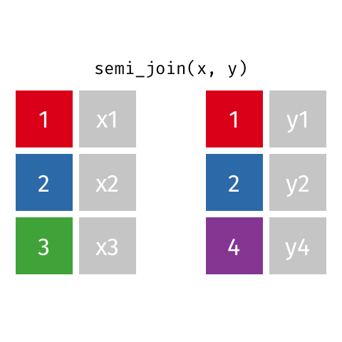

So, for example, let’s imagine that we only removed one subject from `demog` who didn’t fill in information about their native language, and that this subject had a value of 5 for `sub_id` . So `semi_join(stroop, demog_filt, "sub_id")` would return all of the rows from `stroop` except for those with `sub_id = 5`, because there would be no row with `sub_id = 5` in `demog_filt`.

While we’re at it, we’ll also code what condition each trial is in, using the variable `congruency`, calling it “congruent” if the value of `ink_colour` for a given row matches the value of `word` for that same row (`ink_colour == word`), and calling it “incongruent” otherwise.

We won’t remove the inaccurate trials or the missing values yet, because we need to count them first.

```r
stroop2 <- stroop %>%
  semi_join(demog_filt, "sub_id") %>% # keep subjects with full demographic info
  mutate(congruency = if_else(ink_colour == word, "congruent", "incongruent"))
```

Let’s now count the timed-out responses (NAs) and the inaccurate responses. To work with `NA` values, you need the function `is.na()` which returns `TRUE` if the value in question is `NA` and `FALSE` otherwise.

We know that a response is inaccurate if the value of `response` doesn’t match the value of `ink_colour`.

```r
n_excluded_trials <- filter(stroop2, is.na(response)) %>% nrow()
n_incorrect <- filter(stroop2, response != ink_colour) %>% nrow()
```

Now let’s get rid of the rejects, and store the result in `stroop3`.

```r
stroop3 <- stroop2 %>%
  filter(!is.na(response) & (response == ink_colour))
```

Counting the remaining trials is easy – it’s just `nrow(stroop3)`. So our `answers` code chunk for the second paragraph looks like this:

```r
stroop2 <- stroop %>%
  semi_join(demog_filt, "sub_id") %>% # keep subjects with full demographic info
  mutate(congruency = if_else(ink_colour == word, "congruent", "incongruent"))

n_excluded_trials <- filter(stroop2, is.na(response)) %>% nrow()
n_incorrect <- filter(stroop2, response != ink_colour) %>% nrow()

stroop3 <- stroop2 %>%
  filter(!is.na(response) & (response == ink_colour))

n_correct <- nrow(stroop3)
```

yielding:

We excluded 8 trials because participants did not respond before the response deadline (resulting in a missing value) and 16 trials because participants responded incorrectly, leaving 936 trials for analysis.

## Paragraph 3: Descriptive statistics

Now we’ll hack into the trial data to calculate descriptive statistics and to prepare the data for our inferential test.

The overall mean reaction time was 0 ms (SD = 0) for congruent trials and 0 ms (SD = 0) for incongruent trials, yielding an overall Stroop effect of 0 ms (SD = 0). The Stroop effect for native speakers (M = 0; SD = 0) was numerically *choose one*: larger/smaller than the Stroop effect for non-native speakers (M = 0; SD = 0).

Note that we need to calculate a “Stroop effect”, which is defined as the difference between incongruent and congruent response times. And we will ultimately need to have a Stroop effect calculated for each speaker. So we’ll need to (1) calculate means for each condition for each speaker and then (2) calculate the differences.

```r
subj_means <- stroop3 %>%
  group_by(sub_id, congruency) %>%
  summarise(m = mean(rt)) %>%
  ungroup()

subj_means
```

```
## # A tibble: 192 x 3
##    sub_id congruency      m
##     <int> <chr>       <dbl>
##  1      1 congruent    693.
##  2      1 incongruent  753.
##  3      2 congruent    683.
##  4      2 incongruent  754.
##  5      3 congruent    604.
##  6      3 incongruent  700.
##  7      4 congruent    644.
##  8      4 incongruent  746.
##  9      5 congruent    664
## 10      5 incongruent  797.
## # … with 182 more rows
```

OK, that looks good, but how do we now calculate the Stroop effect for each speaker? Let’s transform the data from long to wide using `pivot_wider()` from the `tidyr` package, which was loaded when we loaded in the tidyverse.

```r
wide_data <- subj_means %>%
  pivot_wider(names_from = congruency, values_from = m) %>%
  mutate(effect = incongruent - congruent)

wide_data
```

```
## # A tibble: 96 x 4
##    sub_id congruent incongruent effect
##     <int>     <dbl>       <dbl>  <dbl>
##  1      1      693.        753.   60
##  2      2      683.        754.   70.7
##  3      3      604.        700.   95.8
##  4      4      644.        746.  102.
##  5      5      664         797.  133.
##  6      6      601.        691.   90
##  7      7      576.        685   109.
##  8      8      618         672.   54.4
##  9      9      605         700    95
## 10     10      603.        640.   37.1
## # … with 86 more rows
```

There is one thing that we are missing: which group (native or non-native) each subject belongs to. We can get this using an `inner_join()`.

```r
joined <- wide_data %>%
  inner_join(demog_filt, "sub_id")

joined
```

```
## # A tibble: 96 x 6
##    sub_id congruent incongruent effect   age native_speaker
##     <int>     <dbl>       <dbl>  <dbl> <int> <chr>
##  1      1      693.        753.   60      21 no
##  2      2      683.        754.   70.7    20 no
##  3      3      604.        700.   95.8    19 yes
##  4      4      644.        746.  102.     20 no
##  5      5      664         797.  133.     22 no
##  6      6      601.        691.   90      20 yes
##  7      7      576.        685   109.     18 yes
##  8      8      618         672.   54.4    23 yes
##  9      9      605         700    95      24 yes
## 10     10      603.        640.   37.1    24 yes
## # … with 86 more rows
```

Now we’re ready to calculate means for each of the two congruent/incongruent conditions, and for the Stroop effect.

```r
by_cond <- joined %>%
  summarise(m_cong = mean(congruent), sd_cong = sd(congruent),
            m_incg = mean(incongruent), sd_incg = sd(incongruent),
            m_eff = mean(effect), sd_eff = sd(effect))

by_cond
```

```
## # A tibble: 1 x 6
##   m_cong sd_cong m_incg sd_incg m_eff sd_eff
##    <dbl>   <dbl>  <dbl>   <dbl> <dbl>  <dbl>
## 1   646.    61.5   722.    53.9  75.9   68.1
```

Now let’s calculate the mean effects for each of the two groups.

```r
stats_by_group <- joined %>%
  group_by(native_speaker) %>%
  summarise(m = mean(effect), sd = sd(effect)) %>%
  ungroup()

stats_by_group
```

```
## # A tibble: 2 x 3
##   native_speaker     m    sd
##   <chr>          <dbl> <dbl>
## 1 no              51.7  69.7
## 2 yes             96.4  60.0
```

We can get this is into a format that is easier to pull values from by using `pivot_wider()`; this step is not strictly necessary, but will simply help us out in the final section below where we’re transcribing the values into the paragraph.

```r
sbyg_wide <- pivot_wider(stats_by_group,
                         names_from = native_speaker,
                         values_from = c("m", "sd"))

sbyg_wide
```

```
## # A tibble: 1 x 4
##    m_no m_yes sd_no sd_yes
##   <dbl> <dbl> <dbl>  <dbl>
## 1  51.7  96.4  69.7   60.0
```

OK, we’re done, here’s the full code to define the variables for the third paragraph.

```r
subj_means <- stroop3 %>%
  group_by(sub_id, congruency) %>%
  summarise(m = mean(rt)) %>%
  ungroup()

wide_data <- subj_means %>%
  pivot_wider(names_from = congruency, values_from = m) %>%
  mutate(effect = incongruent - congruent)

joined <- wide_data %>%
  inner_join(demog_filt, "sub_id")

by_cond <- joined %>%
  summarise(m_cong = mean(congruent), sd_cong = sd(congruent),
            m_incg = mean(incongruent), sd_incg = sd(incongruent),
            m_eff = mean(effect), sd_eff = sd(effect))

mean_congruent <- by_cond %>% pull(m_cong) %>% round(2)
sd_congruent <- by_cond %>% pull(sd_cong) %>% round(2)
mean_incongruent <- by_cond %>% pull(m_incg) %>% round(2)
sd_incongruent <- by_cond %>% pull(sd_incg) %>% round(2)
mean_stroop <- by_cond %>% pull(m_eff) %>% round(2)
sd_stroop <- by_cond %>% pull(sd_eff) %>% round(2)

stats_by_group <- joined %>%
  group_by(native_speaker) %>%
  summarise(m = mean(effect), sd = sd(effect)) %>%
  ungroup()

sbyg_wide <- pivot_wider(stats_by_group,
                         names_from = native_speaker,
                         values_from = c("m", "sd"))

mean_native_stroop <- sbyg_wide %>% pull(m_yes) %>% round(2)
sd_native_stroop <- sbyg_wide %>% pull(sd_yes) %>% round(2)
mean_nonnative_stroop <- sbyg_wide %>% pull(m_no) %>% round(2)
sd_nonnative_stroop <- sbyg_wide %>% pull(sd_no) %>% round(2)
larger_or_smaller <- if_else(mean_native_stroop > mean_nonnative_stroop,
                             "larger", "smaller")
```

Our third paragraph now looks like so:

The overall mean reaction time was 645.73 ms (SD = 61.51) for congruent trials and 721.68 ms (SD = 53.89) for incongruent trials, yielding an overall Stroop effect of 75.95 ms (SD = 68.08). The Stroop effect for native speakers (M = 96.45; SD = 60.05) was numerically larger than the Stroop effect for non-native speakers (M = 51.71; SD = 69.67).

## Paragraph 4: Inferential statistics

Now for the easy part: running the t-test. Parsing out the results into variables is, unfortunately, less easy.

According to Welch’s t-test (which does not assume equal variances) with $\alpha = .05$, this difference *choose one*: was/was not statistically significant, $t$(0) = 0, $p$ = 1.000. The 95% confidence interval for the mean difference was [0, 0], with an effect size (Cohen’s $d$) of 0.

```r
my_t <- t.test(effect ~ native_speaker, joined)

my_t
```

```
##
##  Welch Two Sample t-test
##
## data:  effect by native_speaker
## t = -3.3377, df = 85.547, p-value = 0.001252
## alternative hypothesis: true difference in means is not equal to 0
## 95 percent confidence interval:
##  -71.38532 -18.08968
## sample estimates:
##  mean in group no mean in group yes
##           51.7125           96.4500
```

Note that almost all of the output we need is here: the $t$ value, the $p$ value, degrees of freedom, confidence interval. It is also reassuring to find that the means for each group match up with what we got above for `stats_by_group`.

However, note that the subtraction of means went in the opposite direction from what we expected: mean for nonnative minus means for native. This is because R organizes the levels of the IV `native_speaker` in alphabetical order (no, yes), and then subtracts the latter category (yes) from the first category (no). If we want it to go in the other direction, we need to relevel the `native_speaker` factor. This is a tiny thing, and not strictly necessary, but will make the results more sensible. We’ll do this using `forcats::fct_relevel()`, which is part of the tidyverse. Then we’ll convert `my_t` into a table with the results using `broom::tidy()`.

```r
data_releveled <- joined %>%
  mutate(native_speaker = fct_relevel(native_speaker, "yes"))
## you might want to look at data_releveled to see the change

my_t <- t.test(effect ~ native_speaker, data_releveled)

t_table <- broom::tidy(my_t)

t_table
```

```
## # A tibble: 1 x 10
##   estimate estimate1 estimate2 statistic p.value parameter conf.low
##      <dbl>     <dbl>     <dbl>     <dbl>   <dbl>     <dbl>    <dbl>
## 1     44.7      96.4      51.7      3.34 0.00125      85.5     18.1
## # … with 3 more variables: conf.high <dbl>, method <chr>,
## #   alternative <chr>
```

The one thing that is still missing is Cohen’s $d$. If you look it up on the internet, you’ll find something like:

$$\frac{\lvert M_1 - M_2 \rvert}{\sigma_{pooled}}$$

In plain English, take the absolute value of the difference between the two group means, $M_1$ and $M_2$, and divide by $\sigma_{pooled}$, the “pooled”" standard deviation. In this case, $\sigma_{pooled}$ is just the overall standard deviation for the Stroop effect. We can get this with:

```r
sigma_pooled <- joined %>%
  summarise(sd = sd(effect)) %>%
  pull(sd)
```

So $\sigma_{pooled} = 68.08$.

In sum, here’s the full code to fill in the correct values for the fourth paragraph:

```r
data_releveled <- joined %>%
  mutate(native_speaker = fct_relevel(native_speaker, "yes"))

my_t <- t.test(effect ~ native_speaker, data_releveled)

t_table <- broom::tidy(my_t)

degrees_of_freedom <- t_table %>% pull(parameter) %>% round(2)
t_statistic <- t_table %>% pull(statistic) %>% round(2)
p_value <- t_table %>% pull(p.value) # don't round; rounding in inline code
was_or_was_not <- if_else(p_value < .05, "was", "was not")
conf_int_lower <- t_table %>% pull(conf.low) %>% round(2)
conf_int_upper <- t_table %>% pull(conf.high) %>% round(2)

sigma_pooled <- joined %>%
  summarise(sd = sd(effect)) %>%
  pull(sd)

abs_diff_means <- abs(pull(sbyg_wide, m_no) - pull(sbyg_wide, m_yes))
cohen_d <-  round(abs_diff_means / sigma_pooled, 2)
```

and here’s how it will look.

According to Welch’s t-test (which does not assume equal variances) with $\alpha = .05$, this difference was statistically significant, $t$(85.55) = 3.34, $p$ = 0.001. The 95% confidence interval for the mean difference was [18.09, 71.39], with an effect size (Cohen’s $d$) of 0.66.

## Pulling it all together

OK, we’re done! So your full script would look something like this:

```r
## first paragraph
n_subj <- nrow(demog)
n_deleted_subj <- nrow(demog) - nrow(demog_filt)
n_remaining_subj <- nrow(demog_filt)

n_native <- demog_filt %>%
  filter(native_speaker == "yes") %>%
  nrow()

n_nonnative <- demog_filt %>%
  filter(native_speaker == "no") %>%
  nrow()

age_stats <- demog_filt %>%
  summarise(m = mean(age), sd = sd(age))

mean_age <- age_stats %>% pull(m) %>% round(2)
sd_age <- age_stats %>% pull(sd) %>% round(2)

## second paragraph
stroop2 <- stroop %>%
  semi_join(demog_filt, "sub_id") %>% # keep subjects with full demographic info
  mutate(congruency = if_else(ink_colour == word, "congruent", "incongruent"))

n_excluded_trials <- filter(stroop2, is.na(response)) %>% nrow()
n_incorrect <- filter(stroop2, response != ink_colour) %>% nrow()

stroop3 <- stroop2 %>%
  filter(!is.na(response) & (response == ink_colour))

n_correct <- nrow(stroop3)

## third paragraph
subj_means <- stroop3 %>%
  group_by(sub_id, congruency) %>%
  summarise(m = mean(rt)) %>%
  ungroup()

wide_data <- subj_means %>%
  pivot_wider(names_from = congruency, values_from = m) %>%
  mutate(effect = incongruent - congruent)

joined <- wide_data %>%
  inner_join(demog_filt, "sub_id")

by_cond <- joined %>%
  summarise(m_cong = mean(congruent), sd_cong = sd(congruent),
            m_incg = mean(incongruent), sd_incg = sd(incongruent),
            m_eff = mean(effect), sd_eff = sd(effect))

mean_congruent <- by_cond %>% pull(m_cong) %>% round(2)
sd_congruent <- by_cond %>% pull(sd_cong) %>% round(2)
mean_incongruent <- by_cond %>% pull(m_incg) %>% round(2)
sd_incongruent <- by_cond %>% pull(sd_incg) %>% round(2)
mean_stroop <- by_cond %>% pull(m_eff) %>% round(2)
sd_stroop <- by_cond %>% pull(sd_eff) %>% round(2)

stats_by_group <- joined %>%
  group_by(native_speaker) %>%
  summarise(m = mean(effect), sd = sd(effect)) %>%
  ungroup()

sbyg_wide <- pivot_wider(stats_by_group,
                         names_from = native_speaker,
                         values_from = c("m", "sd"))

mean_native_stroop <- sbyg_wide %>% pull(m_yes) %>% round(2)
sd_native_stroop <- sbyg_wide %>% pull(sd_yes) %>% round(2)
mean_nonnative_stroop <- sbyg_wide %>% pull(m_no) %>% round(2)
sd_nonnative_stroop <- sbyg_wide %>% pull(sd_no) %>% round(2)
larger_or_smaller <- if_else(mean_native_stroop > mean_nonnative_stroop,
                             "larger", "smaller")

## fourth paragraph
data_releveled <- joined %>%
  mutate(native_speaker = fct_relevel(native_speaker, "yes"))

my_t <- t.test(effect ~ native_speaker, data_releveled)

t_table <- broom::tidy(my_t)

degrees_of_freedom <- t_table %>% pull(parameter) %>% round(2)
t_statistic <- t_table %>% pull(statistic) %>% round(2)
p_value <- t_table %>% pull(p.value) # don't round; rounding in inline code
was_or_was_not <- if_else(p_value < .05, "was", "was not")
conf_int_lower <- t_table %>% pull(conf.low) %>% round(2)
conf_int_upper <- t_table %>% pull(conf.high) %>% round(2)

sigma_pooled <- joined %>%
  summarise(sd = sd(effect)) %>%
  pull(sd)

abs_diff_means <- abs(pull(sbyg_wide, m_no) - pull(sbyg_wide, m_yes))
cohen_d <-  round(abs_diff_means / sigma_pooled, 2)
```

And your results section should turn out like this:

### Results

We tested 100 participants on a Stroop task to determine if native speakers show a larger Stroop effect than non-native speakers. There were 4 participants who did not respond to the question about being a native speaker. Of the remaining 96 participants, 52 were native speakers and 44 were non-native speakers. The mean age of the participants was 21.24 years (SD = 1.96).

We excluded 8 trials because participants did not respond before the response deadline (resulting in a missing value) and 16 trials because participants responded incorrectly, leaving 936 trials for analysis.

The overall mean reaction time was 645.73 ms (SD = 61.51) for congruent trials and 721.68 ms (SD = 53.89) for incongruent trials, yielding an overall Stroop effect of 75.95 ms (SD = 68.08). The Stroop effect for native speakers (M = 96.45; SD = 60.05) was numerically larger than the Stroop effect for non-native speakers (M = 51.71; SD = 69.67).

According to Welch’s t-test (which does not assume equal variances) with $\alpha = .05$, this difference was statistically significant, $t$(85.55) = 3.34, $p$ = 0.001. The 95% confidence interval for the mean difference was [18.09, 71.39], with an effect size (Cohen’s $d$) of 0.66.

**Note: You may have found other, equivalent ways to complete the task, and perhaps your approach was even more efficient! But what matters most is getting the right results, and doing the task in a reproducible and transparent way.**

## Making a graph

Show your data!

But what data to show? All the trial data? Or just speaker means?

In this case, it might be most sensible to show the individual speaker means, since those are the values you are performing inference over.

Note that the observations need to be in **long** format. We’ll just use the table `subj_means` computed above, joined with `demog_filt` to get the information about native language.

We’ll have lines connecting the two data points for each participant, and superimpose the means on the plot.

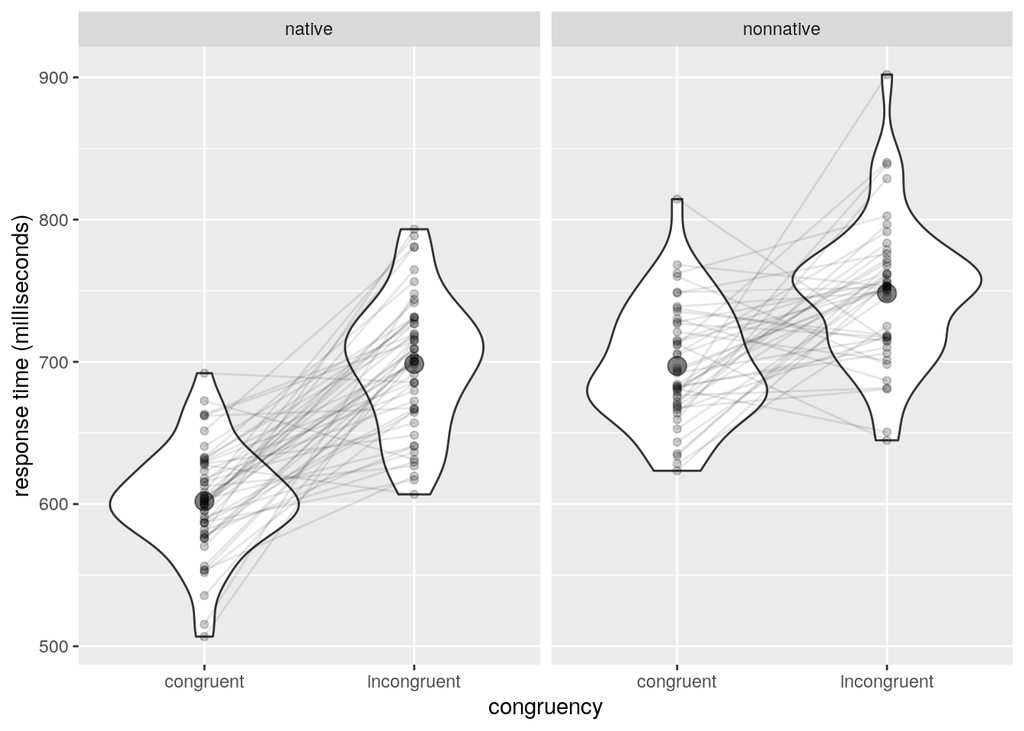

```r
subj_means2 <- subj_means %>%
  inner_join(demog_filt, "sub_id") %>%
  mutate(group = if_else(native_speaker == "yes", "native", "nonnative"))

summary_stats <- stroop3 %>%
  inner_join(demog_filt, "sub_id") %>%
  mutate(group = if_else(native_speaker == "yes", "native", "nonnative")) %>%
  group_by(group, congruency) %>%
  summarise(m = mean(rt))

ggplot(subj_means2, aes(congruency, m)) +
  geom_violin() +
  geom_point(alpha = .2) +
  geom_line(aes(group = sub_id), alpha = .1) +
  facet_wrap(~group) +
  labs(y = "response time (milliseconds)") +
  geom_point(data = summary_stats, size = 4, alpha = .5)
```